# Quantum Heart Prediction

Elvira Khwatenge

2025-03-30

## R Markdown

This is an analysis of a heart disease prediction dataset. The goal is to explore the data, build a predictive model, and evaluate its performance.

## Data Loading and Preprocessing

First, we load the necessary libraries and read the data.

```r
library(tidyverse)
library(caret)
data <- read.csv("Heart Prediction Quantum Dataset.csv")
head(data)
```

```
##   Age Gender BloodPressure Cholesterol HeartRate QuantumPatternFeature
## 1  68      1           105         191       107              8.362241
## 2  58      0            97         249        89              9.249002
## 3  44      0            93         190        82              7.942542
## 4  72      1            93         183       101              6.495155
## 5  37      0           145         166       103              7.653900
## 6  50      1           114         271        73              8.631604
##   HeartDisease
## 1            1
## 2            0
## 3            1
## 4            1
## 5            1
## 6            0
```

```r
str(data)
```

```
## 'data.frame':    500 obs. of  7 variables:
##  $ Age                  : int  68 58 44 72 37 50 68 48 52 40 ...
##  $ Gender               : int  1 0 0 1 0 1 1 0 0 1 ...
##  $ BloodPressure        : int  105 97 93 93 145 114 156 156 116 121 ...
##  $ Cholesterol          : int  191 249 190 183 166 271 225 236 266 255 ...
##  $ HeartRate            : int  107 89 82 101 103 73 73 61 114 96 ...
##  $ QuantumPatternFeature: num  8.36 9.25 7.94 6.5 7.65 ...
##  $ HeartDisease         : int  1 0 1 1 1 0 1 0 0 0 ...
```

```r
sum(is.na(data))
```

```
## [1] 0
```

## Data Processing

preprocess the data by converting categorical variables to factors, checking for outliers, and scaling numerical features.

```r
data$Gender <- as.factor(data$Gender)
data$HeartDisease <- as.factor(data$HeartDisease)

summary(data)
```

```
##       Age        Gender  BloodPressure    Cholesterol      HeartRate
##  Min.   :30.00   0:266   Min.   : 90.0   Min.   :150.0   Min.   : 60.00
##  1st Qu.:43.00   1:234   1st Qu.:111.0   1st Qu.:183.8   1st Qu.: 73.00
##  Median :55.00           Median :132.0   Median :221.0   Median : 89.00
##  Mean   :54.86           Mean   :132.9   Mean   :221.5   Mean   : 88.77
##  3rd Qu.:66.25           3rd Qu.:155.0   3rd Qu.:258.0   3rd Qu.:104.00
##  Max.   :79.00           Max.   :179.0   Max.   :299.0   Max.   :119.00
##  QuantumPatternFeature HeartDisease
##  Min.   : 6.165        0:200
##  1st Qu.: 7.676        1:300
##  Median : 8.323
##  Mean   : 8.317
##  3rd Qu.: 8.936
##  Max.   :10.785
```

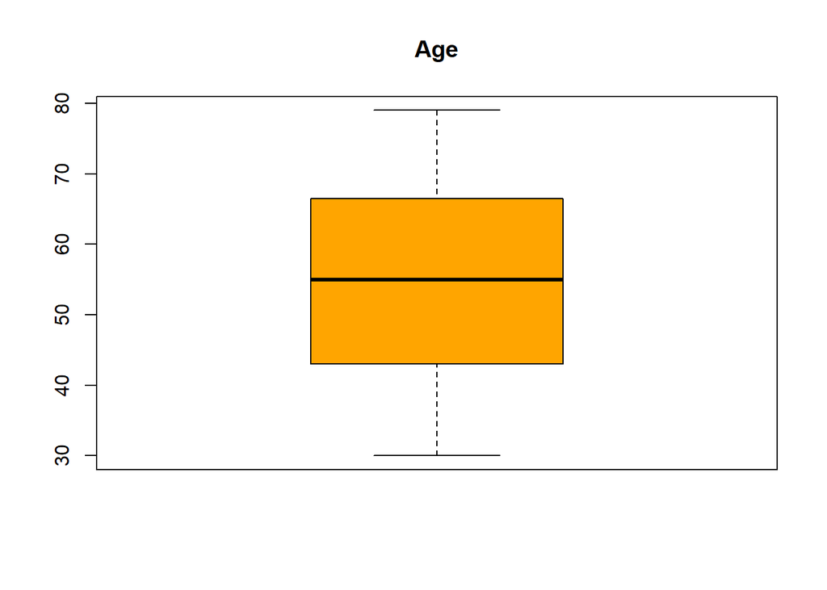

```r
boxplot(data$Age, main="Age",col="orange", border="black")
```

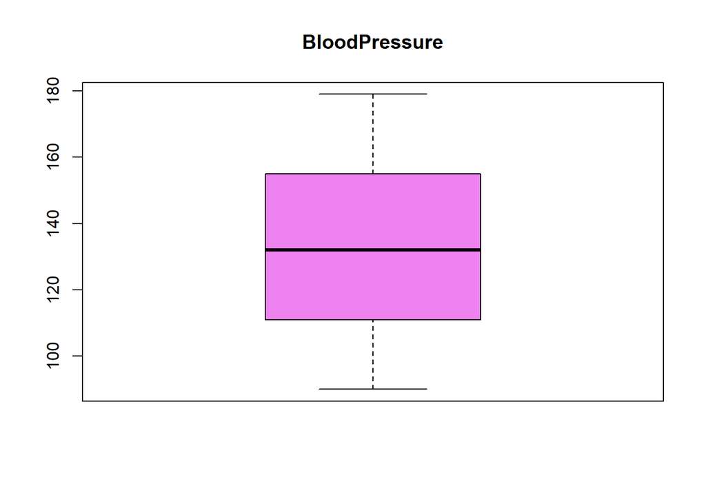

```r
boxplot(data$BloodPressure, main="BloodPressure",col="violet", border="black")
```

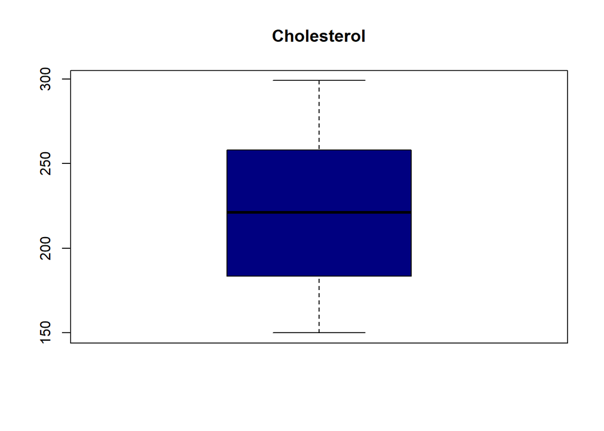

```r
boxplot(data$Cholesterol, main="Cholesterol",col="navy", border="black")
```

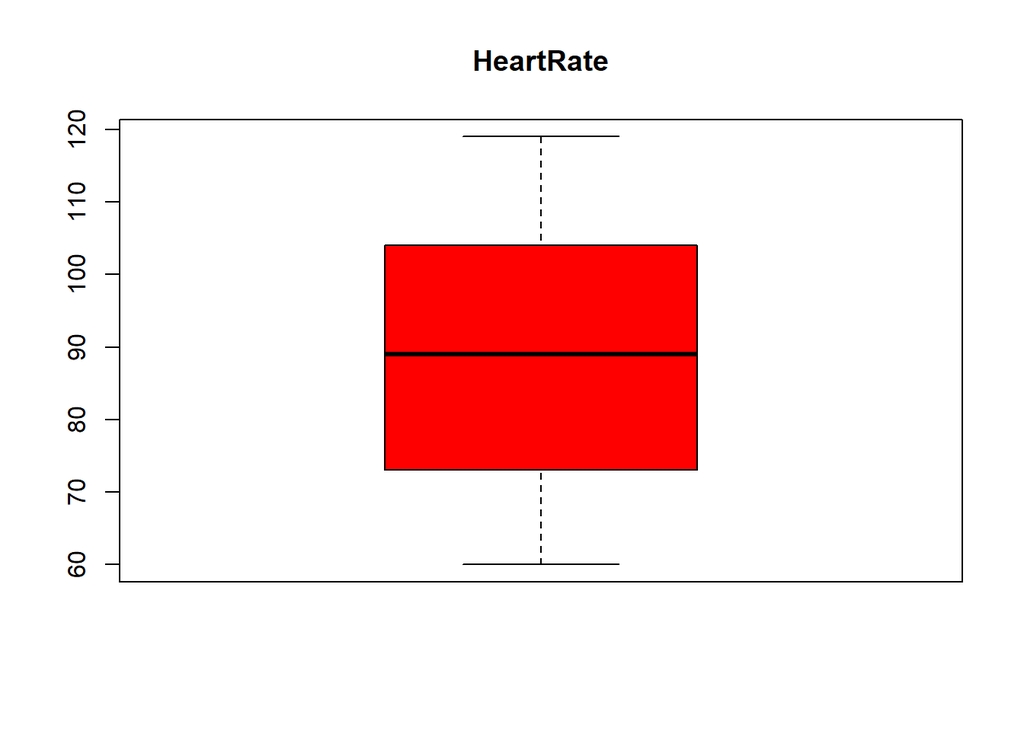

```r
boxplot(data$HeartRate, main="HeartRate",col="red", border="black")
```

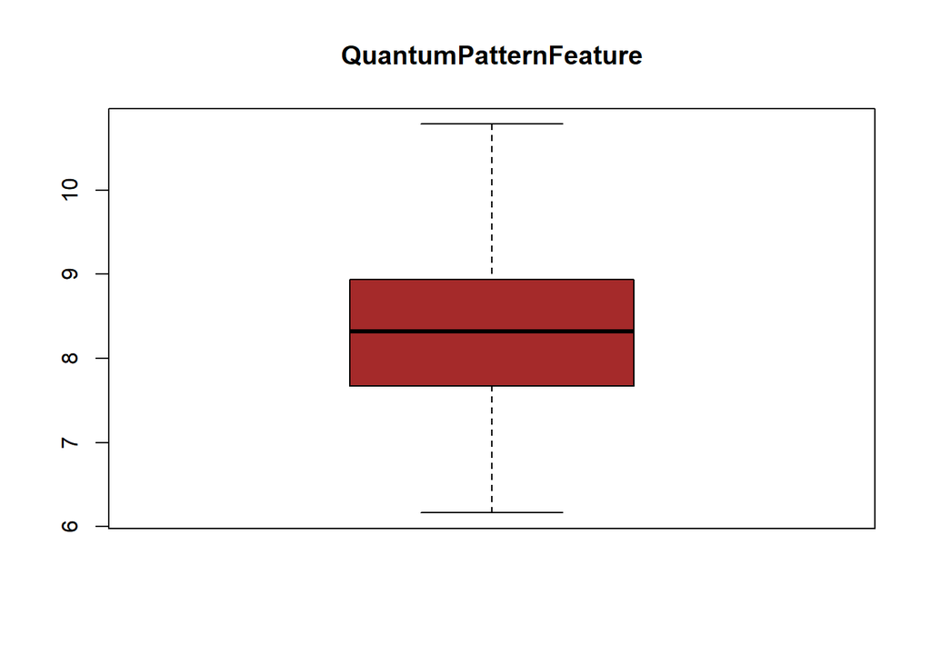

```r
boxplot(data$QuantumPatternFeature, main="QuantumPatternFeature",col="brown", border="black")
```

```r
Q1 <- quantile(data$Cholesterol, 0.25)
Q3 <- quantile(data$Cholesterol, 0.75)
IQR <- Q3 - Q1
lower_bound <- Q1 - 1.5 * IQR
upper_bound <- Q3 + 1.5 * IQR

data <- data[data$Cholesterol >= lower_bound & data$Cholesterol <= upper_bound, ]

numerical_features <- c("Age", "BloodPressure", "Cholesterol", "HeartRate", "QuantumPatternFeature")
data[numerical_features] <- scale(data[numerical_features])

head(data)
```

```
##          Age Gender BloodPressure Cholesterol   HeartRate QuantumPatternFeature
## 1  0.9176386      1    -1.0550933  -0.6953369  1.04689080            0.04875145
## 2  0.2190708      0    -1.3579112   0.6269431  0.01343493            1.01301086
## 3 -0.7589240      0    -1.5093202  -0.7181348 -0.38846458           -0.40762679
## 4  1.1970657      1    -1.5093202  -0.8777203  0.70240551           -1.98150828
## 5 -1.2479214      0     0.4589963  -1.2652852  0.81723394           -0.72149462
## 6 -0.3397833      1    -0.7144232   1.1284976 -0.90519252            0.34165582
##   HeartDisease
## 1            1
## 2            0
## 3            1
## 4            1
## 5            1
## 6            0
```

###Exploratory Data Analysis (EDA)

perform EDA to understand the relationships between variables.

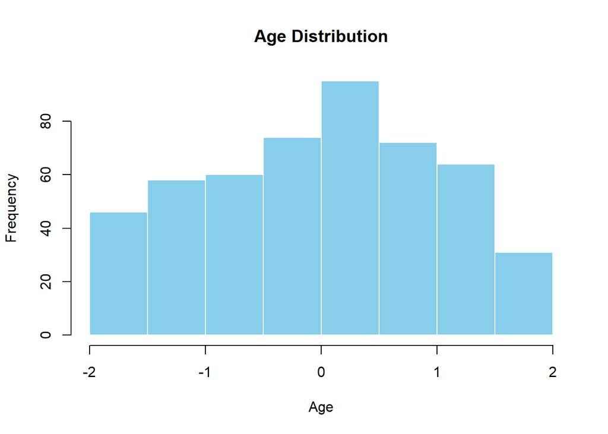

```r
hist(data$Age, main="Age Distribution", xlab="Age", col="skyblue", border="white")
```

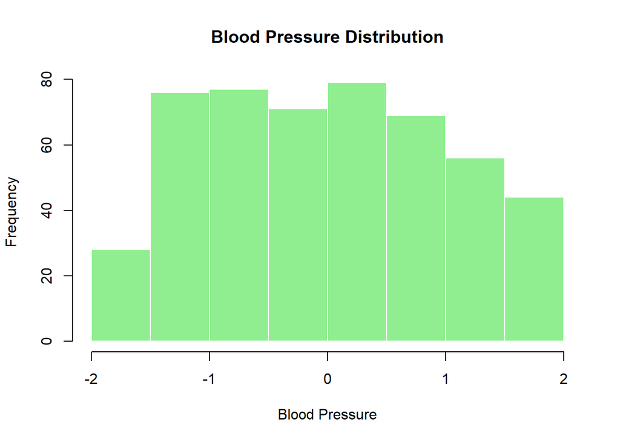

```r
hist(data$BloodPressure, main="Blood Pressure Distribution", xlab="Blood Pressure", col="lightgreen", border="white")
```

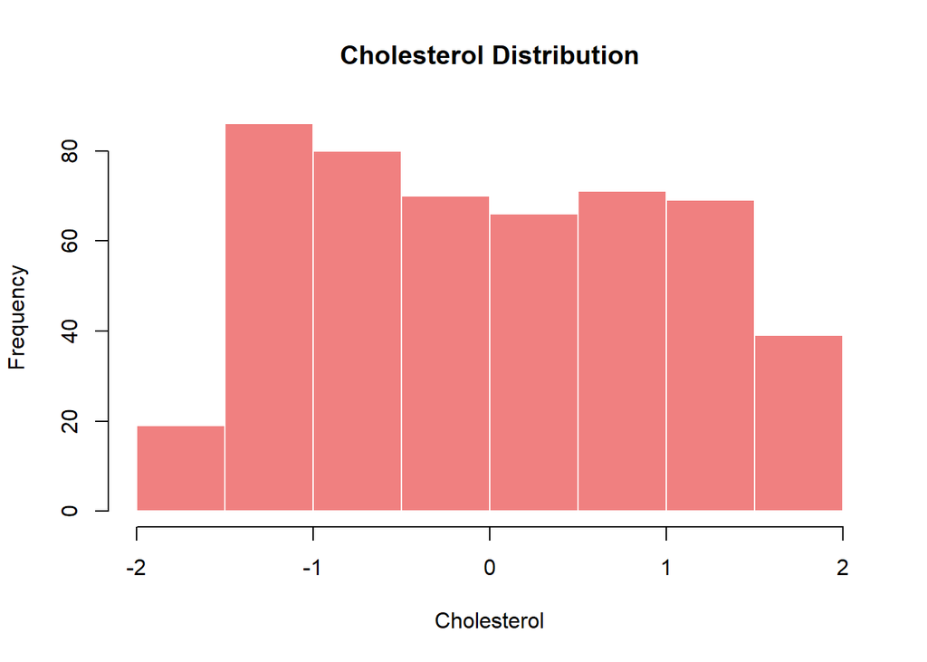

```r
hist(data$Cholesterol, main="Cholesterol Distribution", xlab="Cholesterol", col="lightcoral", border="white")
```

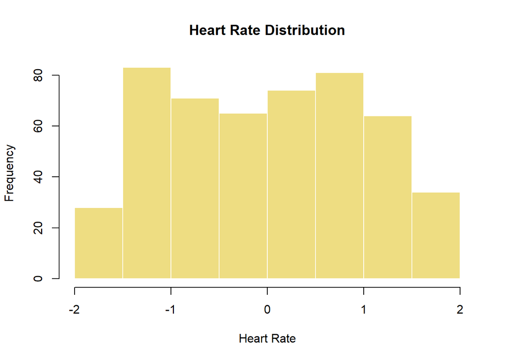

```r
hist(data$HeartRate, main="Heart Rate Distribution", xlab="Heart Rate", col="lightgoldenrod", border="white")
```

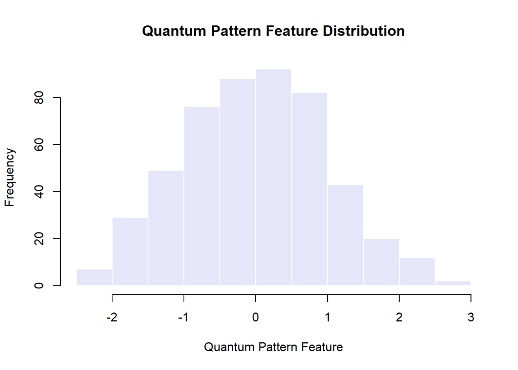

```r
hist(data$QuantumPatternFeature, main="Quantum Pattern Feature Distribution", xlab="Quantum Pattern Feature", col="lavender", border="white")
```

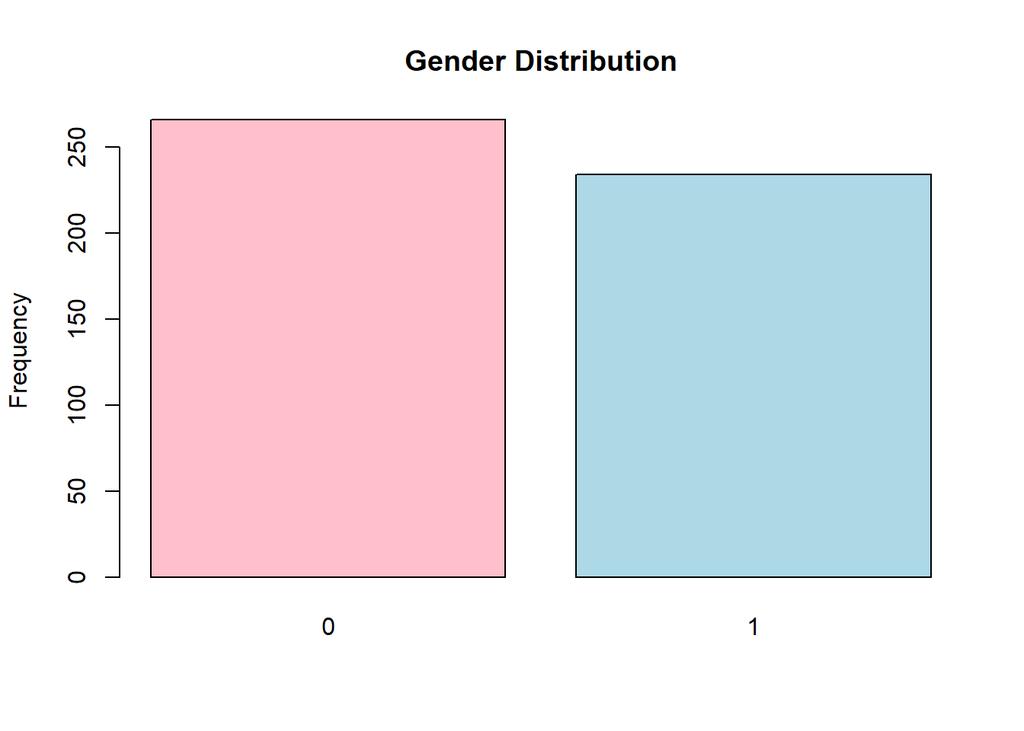

```r
# Bar plots with colors
plot(data$Gender, main="Gender Distribution", ylab="Frequency", col=c("pink", "lightblue"))
```

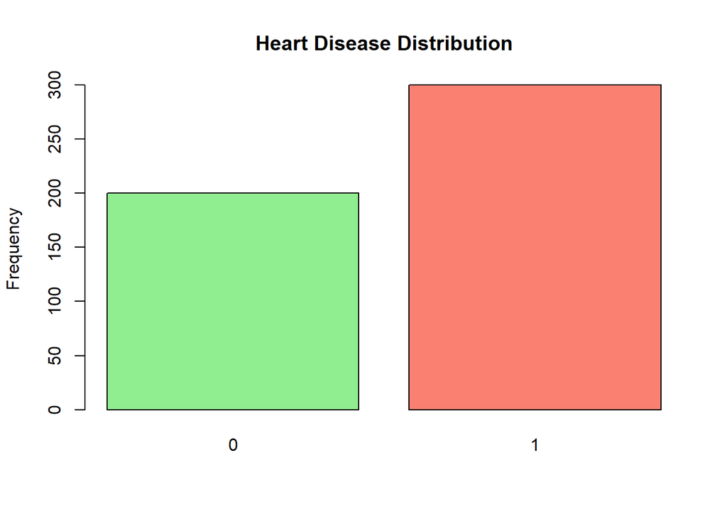

```r
plot(data$HeartDisease, main="Heart Disease Distribution", ylab="Frequency", col=c("lightgreen", "salmon"))
```

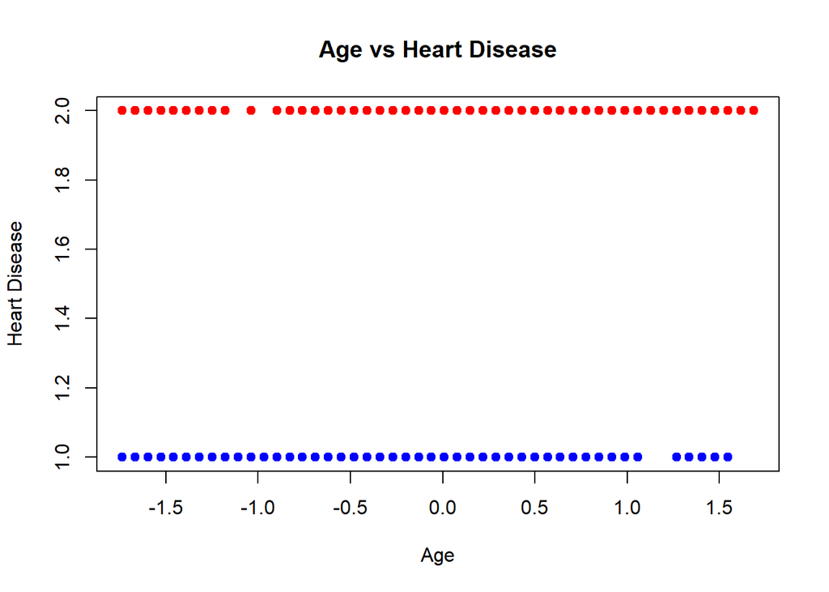

```r
# Scatter plots with colors
plot(data$Age, data$HeartDisease, main="Age vs Heart Disease", xlab="Age", ylab="Heart Disease", col=ifelse(data$HeartDisease == 1, "red", "blue"), pch=19)
```

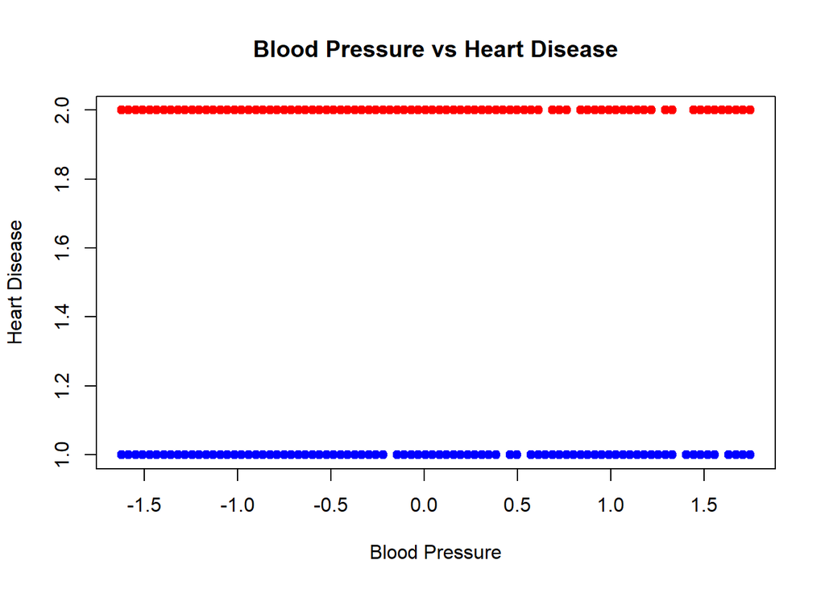

```r
plot(data$BloodPressure, data$HeartDisease, main="Blood Pressure vs Heart Disease", xlab="Blood Pressure", ylab="Heart Disease", col=ifelse(data$HeartDisease == 1, "red", "blue"), pch=19)
```

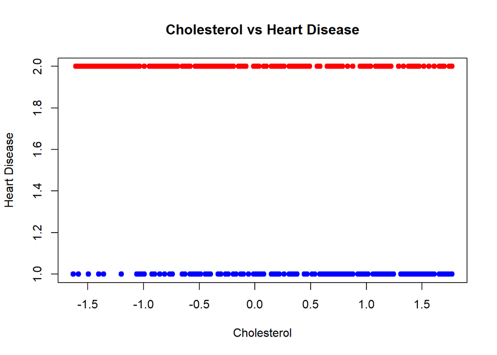

```r
plot(data$Cholesterol, data$HeartDisease, main="Cholesterol vs Heart Disease", xlab="Cholesterol", ylab="Heart Disease", col=ifelse(data$HeartDisease == 1, "red", "blue"), pch=19)
```

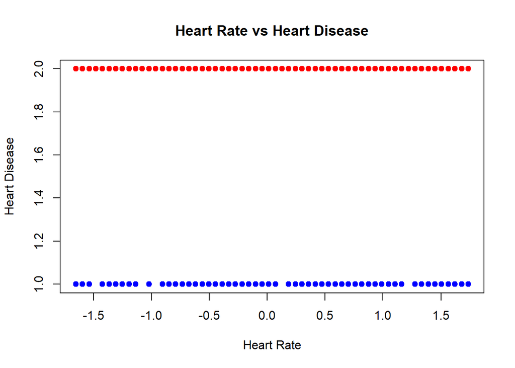

```r
plot(data$HeartRate, data$HeartDisease, main="Heart Rate vs Heart Disease", xlab="Heart Rate", ylab="Heart Disease", col=ifelse(data$HeartDisease == 1, "red", "blue"), pch=19)
```

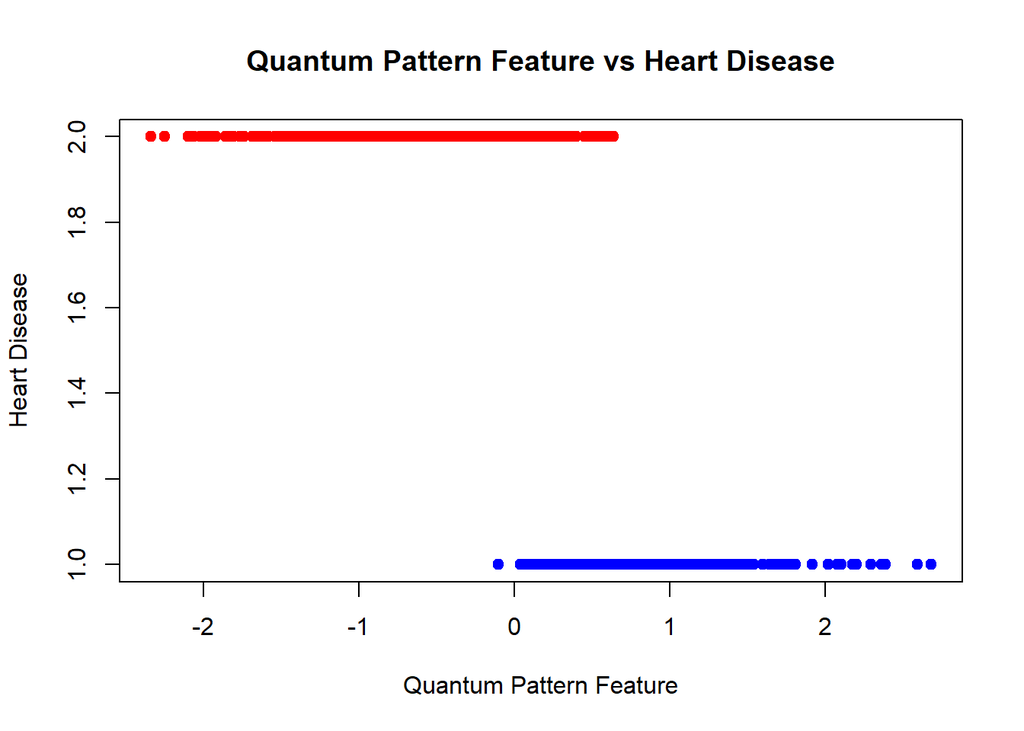

```r
plot(data$QuantumPatternFeature, data$HeartDisease, main="Quantum Pattern Feature vs Heart Disease", xlab="Quantum Pattern Feature", ylab="Heart Disease", col=ifelse(data$HeartDisease == 1, "red", "blue"), pch=19)
```

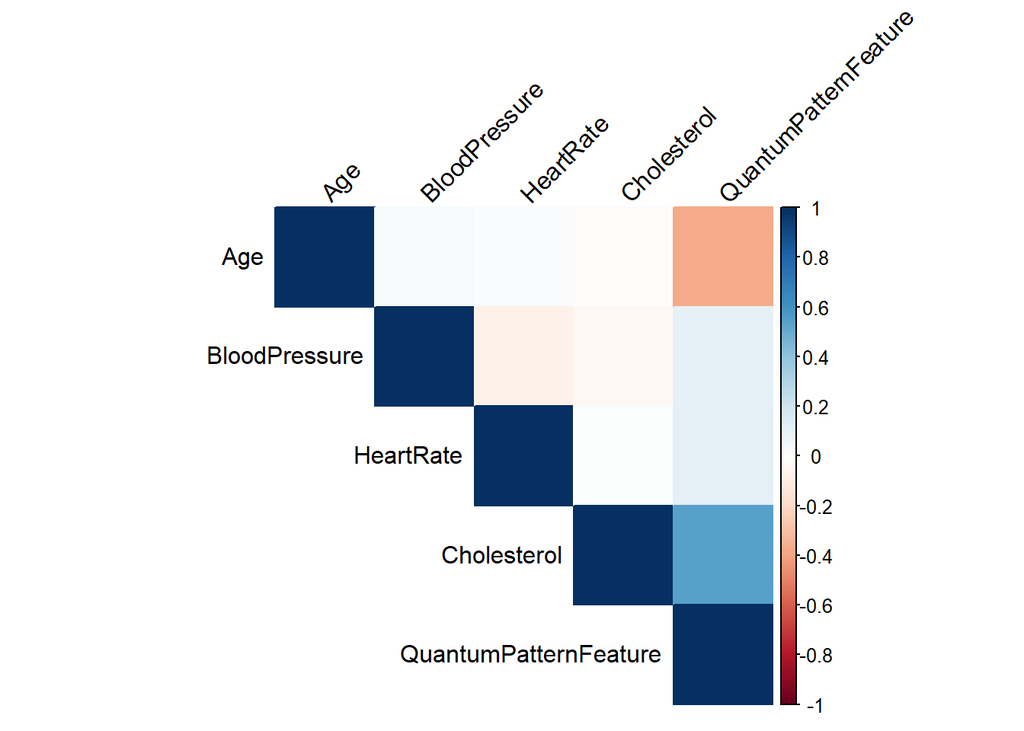

```r
# Select numeric columns and handle missing values
numerical_features <- c("Age", "BloodPressure", "Cholesterol", "HeartRate", "QuantumPatternFeature")
numeric_data <- data[, numerical_features]
numeric_data <- na.omit(numeric_data)

# Remove columns with zero variance (if any)
numeric_data <- numeric_data[, apply(numeric_data, 2, var) != 0]

# Compute correlation matrix
correlation_matrix <- cor(numeric_data, use = "complete.obs")

# Visualize with corrplot
library(corrplot)
corrplot(correlation_matrix, method = "color", type = "upper", order = "hclust",
         tl.col = "black", tl.srt = 45)
```

### Model Building

Build a logistic regression model to predict heart disease

```r
set.seed(123)
train_index <- createDataPartition(data$HeartDisease, p = 0.7, list = FALSE)
train_data <- data[train_index, ]
test_data <- data[-train_index, ]

# Train the logistic regression model
model <- glm(HeartDisease ~ ., data = train_data, family = "binomial")

# Summarize the model
summary(model)
```

```
##
## Call:
## glm(formula = HeartDisease ~ ., family = "binomial", data = train_data)
##
## Coefficients:
##                       Estimate Std. Error z value Pr(>|z|)
## (Intercept)             1.7752     0.4391   4.043 5.27e-05 ***
## Age                    -0.2477     0.2749  -0.901    0.368
## Gender1                 0.2093     0.5015   0.417    0.676
## BloodPressure          -0.1250     0.2349  -0.532    0.595
## Cholesterol             0.1128     0.2723   0.414    0.679
## HeartRate              -0.2070     0.2441  -0.848    0.397
## QuantumPatternFeature  -7.6702     1.0599  -7.237 4.60e-13 ***
## ---
## Signif. codes:  0 '***' 0.001 '**' 0.01 '*' 0.05 '.' 0.1 ' ' 1
##
## (Dispersion parameter for binomial family taken to be 1)
##
##     Null deviance: 471.11  on 349  degrees of freedom
## Residual deviance: 110.27  on 343  degrees of freedom
## AIC: 124.27
##
## Number of Fisher Scoring iterations: 8
```

```r
# Make predictions on the test data
predictions <- predict(model, newdata = test_data, type = "response")
predicted_classes <- ifelse(predictions > 0.5, 1, 0)

# Evaluate the model
confusionMatrix(as.factor(predicted_classes), test_data$HeartDisease)
```

```
## Confusion Matrix and Statistics
##
##           Reference
## Prediction  0  1
##          0 58  8
##          1  2 82
##
##                Accuracy : 0.9333
##                  95% CI : (0.8808, 0.9676)
##     No Information Rate : 0.6
##     P-Value [Acc > NIR] : <2e-16
##
##                   Kappa : 0.8634
##
##  Mcnemar's Test P-Value : 0.1138
##
##             Sensitivity : 0.9667
##             Specificity : 0.9111
##          Pos Pred Value : 0.8788
##          Neg Pred Value : 0.9762
##              Prevalence : 0.4000
##          Detection Rate : 0.3867
##    Detection Prevalence : 0.4400
##       Balanced Accuracy : 0.9389
##
##        'Positive' Class : 0
##
```

# Discussion and Interpretation

## Data Summary and Preprocessing

At the Initial Data Inspection the dataset consisted of 500 observations with 7 variables, including Age, Gender, BloodPressure, Cholesterol, HeartRate, QuantumPatternFeature, and HeartDisease. No missing values were detected.

During Data Type Conversion the Gender and HeartDisease variables were converted to factor variables for appropriate analysis.

Numerical features were scaled to standardize their ranges for model performance.

## Exploratory Data Analysis (EDA)

### Bar Plots

The distribution of males and females in the dataset is critical for understanding potential gender-based risk differences.

Heart Disease Distribution Illustrates the prevalence of heart disease in the sample, providing insight into the overall burden of the disease.

Scatter plots of Age, BloodPressure, Cholesterol, HeartRate, and QuantumPatternFeature versus HeartDisease use color-coding to visualize relationships. Patterns or clusters reveal risk factors or predictive indicators.

Correlation Matrix- heatmap visualizes correlations between numerical features, with stronger correlations indicating potential multicollinearity, which affects model interpretation and feature selection.

### Model Building- Logistic Regression

Coefficients

1. Intercept: 1.7752
2. Age: -0.2477 (p = 0.368)
3. Gender1: 0.2093 (p = 0.676)
4. BloodPressure: -0.1250 (p = 0.595)
5. Cholesterol: 0.1128 (p = 0.679)
6. HeartRate: -0.2070 (p = 0.397)
7. QuantumPatternFeature: -7.6702 (p < 0.001)

### Interpretation:

The QuantumPatternFeature is highly significant (p < 0.001), indicating a strong relationship with heart disease.

Other variables such as Age, Gender, BloodPressure, Cholesterol, and HeartRate are not statistically significant in this model (p > 0.05).

### Model Evaluation (Confusion Matrix)

Accuracy: 93.33%

Sensitivity: 96.67%

Specificity: 91.11%

# Results Interpretation

## Demographic and Health Indicators

#### Gender and Heart Disease Distribution

Knowing the proportions of males and females helps understand potential gender-specific risk factors. Heart Disease Distribution Indicates overall disease burden, useful for resource allocation and public health planning.

## Model Performance

The logistic regression model shows high accuracy (93.33%), sensitivity (96.67%), and specificity (91.11%), demonstrating strong predictive capability. The highly significant QuantumPatternFeature suggests it is a crucial predictor of heart disease within this model.

## Implications

For Academia- Validate QuantumPatternFeature in other datasets, explore interactions, and test other models like Random Forests or Neural Networks.

For Industry- Develop diagnostic tools incorporating the QuantumPatternFeature, and create personalized health monitoring devices.

For Policy Makers- Implement targeted interventions for high-risk groups identified by the model, focusing on QuantumPatternFeature and traditional risk factors.

## Caveats

The model is based on a specific dataset and may not generalize to other populations.

Some features might be correlated, affecting coefficient interpretation.Some variables lack statistical significance (p > 0.05), requiring cautious interpretation.